# R Notebook

# Proyecto Econometría en R

- Andrés Tejeda
- Silvio Urizar
- Víctor Carranza

## Carga y exploración de datos

```r
library(dplyr)
library(ggplot2)
library(psych)
library(corrplot)
library(RColorBrewer)
library(fitdistrplus)
library(tidyr)
library(caret)
library(fastDummies)
```

### Carga

Se inicia cargando los datos para el desarrollo

```r
DfTrain <- read.csv('train.csv')
DfTest <- read.csv('test.csv')
```

### Exploración del set de entrenamiento

Se procede a conocer el tipo de información y datos en este dataset:

```r
sample_n(DfTrain,size = 20)
```

| id | longitude | latitude | housing_median_age | total_rooms | total_bedrooms | population | households | median_income | median_house_value | ocean_proximity |
| --- | --- | --- | --- | --- | --- | --- | --- | --- | --- | --- |
| 5524 | -118.36 | 33.98 | 40 | 1113 | 234 | 584 | 231 | 3.0927 | 316000 | <1H OCEAN |
| 8703 | -118.35 | 33.86 | 24 | 2139 | 481 | 971 | 418 | 4.3859 | 271300 | <1H OCEAN |
| 12373 | -116.40 | 33.78 | 8 | 3059 | 500 | 612 | 208 | 6.8729 | 259200 | INLAND |
| 17078 | -122.20 | 37.48 | 41 | 733 | 155 | 652 | 140 | 5.1654 | 233600 | NEAR BAY |
| 20400 | -118.86 | 34.22 | 22 | 1230 | 200 | 673 | 195 | 6.2708 | 251400 | <1H OCEAN |
| 18975 | -122.04 | 38.24 | 22 | 2761 | 757 | 2612 | 641 | 1.6875 | 87500 | INLAND |
| 13544 | -117.31 | 34.15 | 34 | 2037 | 385 | 1195 | 391 | 3.9231 | 96000 | INLAND |
| 19655 | -120.86 | 37.49 | 37 | 1084 | 271 | 893 | 236 | 1.6213 | 69500 | INLAND |
| 19718 | -121.67 | 39.26 | 29 | 3041 | 683 | 2106 | 687 | 1.6315 | 58000 | INLAND |
| 7921 | -118.07 | 33.86 | 28 | 1789 | 352 | 1347 | 330 | 3.4250 | 189700 | <1H OCEAN |

[output cut: 10 more lines]

```r
str(DfTrain)
```

```
'data.frame':   14447 obs. of  11 variables:
 $ id                : int  9744 13893 18277 16176 8843 7653 14056 18819 17145 16187 ...
 $ longitude         : num  -122 -116 -122 -122 -118 ...
 $ latitude          : num  36.8 34.1 37.3 37.7 34.1 ...
 $ housing_median_age: int  15 37 35 52 28 28 23 40 18 52 ...
 $ total_rooms       : int  2191 452 1172 126 4001 2152 3999 690 1636 107 ...
 $ total_bedrooms    : int  358 109 184 24 1352 415 1182 129 414 79 ...
 $ population        : int  1150 184 512 37 1799 1623 2051 305 853 167 ...
 $ households        : int  330 59 175 27 1220 429 1130 110 439 53 ...
 $ median_income     : num  4.8 3.73 7.36 10.23 2.58 ...
 $ median_house_value: num  227500 65800 500001 225000 272900 ...
 $ ocean_proximity   : chr  "<1H OCEAN" "INLAND" "<1H OCEAN" "NEAR BAY" ...
```

Se tiene que el set de entrenamiento se compone de 9 variables independientes, siendo la variable dependiente *median_house_value*, y las variables dependientes son:

- **longitud:** coordenada de longitud de la ubicación
- **latitud:** coordenada de latitud de la ubicación
- **housing_median_age:** la edad mediana de las casas del sector
- **total_rooms:** cantidad total de habitaciones que tienen las casas en el sector descrito
- **total_bedrooms:** cantidad total de dormitorios que tienen las casas en el sector descrito
- **population:** población estimada del sector descrito
- **households:** cantidad de casas en el sector descrito
- **median_income:** ingreso mediano anual por casa en decenas de miles de dólares en el sector descrito.
- **median_house_value:** valor mediano de una vivienda en el sector descrito en dólares
- **ocean_proximity:** descripción geográfico del sector en función de cuán cercano al mar se encuentra

Al ver la descripción de las variables, es fácil notar que las dimensionales no son uniformes. Por ejemplo, *total_rooms*, *total_bedrooms* y *population* son variables que describen magnitudes por sector, mientras que *median_income* describen magnitudes por casa. Es recomendable que los datos tengan, en la manera de lo posible, uniformidad en las dimensionales.

También se nota que los valores no están balanceados en este set de datos. Algunos están en decenas de miles, otros en unidades, algunos tienen datos con máximos y medias en los rangos de los miles, y otros en unidades. Esto puede dar problemas al momento de implementar un modelo.

Puede notarse que la variable *ocean_proximity* es una variable de tipo categórica. Los valores que puede obtener son:

```r
unique(DfTrain$ocean_proximity)
```

```
[1] "<1H OCEAN"  "INLAND"     "NEAR BAY"   "NEAR OCEAN" "ISLAND"
```

También se obtienen los parámetros estadísticos de las columnas del set

```r
describe(DfTrain)
```

|  | vars | n | mean | sd | median | trimmed | mad | min | max | range | skew | kurtosis | se |
| --- | --- | --- | --- | --- | --- | --- | --- | --- | --- | --- | --- | --- | --- |
| id | 1 | 14447 | 10275.45 | 5957.14 | 10210.00 | 10267.07 | 7639.84 | 1.00 | 20640.00 | 20639.00 | 0.01 | -1.20 | 49.56 |
| longitude | 2 | 14447 | -119.58 | 2.00 | -118.50 | -119.53 | 1.90 | -124.30 | -114.31 | 9.99 | -0.30 | -1.33 | 0.02 |
| latitude | 3 | 14447 | 35.64 | 2.14 | 34.26 | 35.52 | 1.85 | 32.54 | 41.95 | 9.41 | 0.46 | -1.13 | 0.02 |
| housing_median_age | 4 | 14447 | 28.85 | 12.59 | 29.00 | 28.72 | 14.83 | 1.00 | 52.00 | 51.00 | 0.04 | -0.79 | 0.10 |
| total_rooms | 5 | 14447 | 2635.29 | 2215.29 | 2121.00 | 2287.70 | 1180.15 | 2.00 | 39320.00 | 39318.00 | 4.38 | 36.53 | 18.43 |
| total_bedrooms | 6 | 14310 | 537.78 | 424.01 | 433.00 | 470.39 | 240.18 | 1.00 | 6445.00 | 6444.00 | 3.52 | 22.88 | 3.54 |
| population | 7 | 14447 | 1425.17 | 1123.73 | 1163.00 | 1253.52 | 650.86 | 6.00 | 28566.00 | 28560.00 | 4.13 | 42.95 | 9.35 |
| households | 8 | 14447 | 500.12 | 386.18 | 408.00 | 440.77 | 222.39 | 1.00 | 6082.00 | 6081.00 | 3.50 | 23.07 | 3.21 |
| median_income | 9 | 14447 | 3.86 | 1.89 | 3.54 | 3.65 | 1.56 | 0.50 | 15.00 | 14.50 | 1.67 | 5.08 | 0.02 |
| median_house_value | 10 | 14447 | 206873.69 | 115263.89 | 179700.00 | 192892.67 | 101409.84 | 14999.00 | 500001.00 | 485002.00 | 0.97 | 0.32 | 958.97 |

[output cut: 1 more lines]

```r
summary(DfTrain)
```

```
       id          longitude         latitude     housing_median_age  total_rooms    total_bedrooms
 Min.   :    1   Min.   :-124.3   Min.   :32.54   Min.   : 1.00      Min.   :    2   Min.   :   1.0
 1st Qu.: 5140   1st Qu.:-121.8   1st Qu.:33.93   1st Qu.:18.00      1st Qu.: 1444   1st Qu.: 295.0
 Median :10210   Median :-118.5   Median :34.26   Median :29.00      Median : 2121   Median : 433.0
 Mean   :10275   Mean   :-119.6   Mean   :35.64   Mean   :28.85      Mean   : 2635   Mean   : 537.8
 3rd Qu.:15449   3rd Qu.:-118.0   3rd Qu.:37.72   3rd Qu.:37.00      3rd Qu.: 3138   3rd Qu.: 647.0
 Max.   :20640   Max.   :-114.3   Max.   :41.95   Max.   :52.00      Max.   :39320   Max.   :6445.0
                                                                                     NA's   :137
   population      households     median_income     median_house_value ocean_proximity
 Min.   :    6   Min.   :   1.0   Min.   : 0.4999   Min.   : 14999     Length:14447
 1st Qu.:  786   1st Qu.: 280.0   1st Qu.: 2.5671   1st Qu.:119600     Class :character
 Median : 1163   Median : 408.0   Median : 3.5350   Median :179700     Mode  :character
 Mean   : 1425   Mean   : 500.1   Mean   : 3.8639   Mean   :206874
 3rd Qu.: 1722   3rd Qu.: 604.5   3rd Qu.: 4.7229   3rd Qu.:264600
 Max.   :28566   Max.   :6082.0   Max.   :15.0001   Max.   :500001
```

Puede observarse que la variable *total_bedrooms* posee 137 valores *NA*. Para verificar esto, se analiza la columna

```r
sum(is.na(DfTrain$total_bedrooms))
```

```
[1] 137
```

Estos valores nulos se trabajarán en la sección de limpieza de datos.

Para obtener información sobre la variable a predecir, es muy conveniente conocer su distribución e información

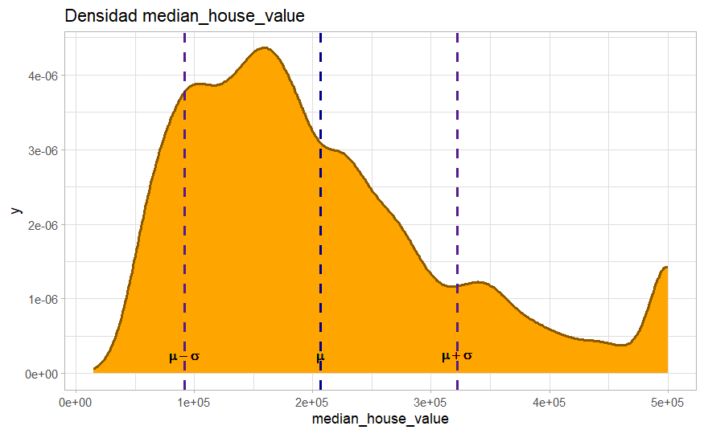

```r
ggplot(data = DfTrain, aes(x = median_house_value))+
geom_density(stat = 'density', col = 'orange4', fill = 'orange', lwd = 1)+
  geom_vline(aes(xintercept = mean(median_house_value)), col = 'darkblue', lwd = 1, linetype = 'dashed') +
  geom_vline(aes(xintercept = (mean(median_house_value)+ sd(median_house_value))), col = 'purple4', lwd = 0.9, linetype = 'dashed') +
  geom_vline(aes(xintercept = (mean(median_house_value)- sd(median_house_value))), col = 'purple4', lwd = 0.9, linetype = 'dashed') +
  theme_light() + ggtitle('Densidad median_house_value')+
  geom_text(aes(mean(median_house_value),0,label = 'mu', vjust = -1), parse = TRUE) +
  geom_text(aes((mean(median_house_value)- sd(median_house_value)),0,label = paste('mu', '-', 'sigma') , vjust = -1), parse = TRUE) +
  geom_text(aes((mean(median_house_value)+ sd(median_house_value)),0,label = paste('mu', '+', 'sigma') , vjust = -1), parse = TRUE)
```

```
summary statistics
------
min:  14999   max:  500001
median:  179700
mean:  206873.7
estimated sd:  115263.9
estimated skewness:  0.9733412
estimated kurtosis:  3.319906
```

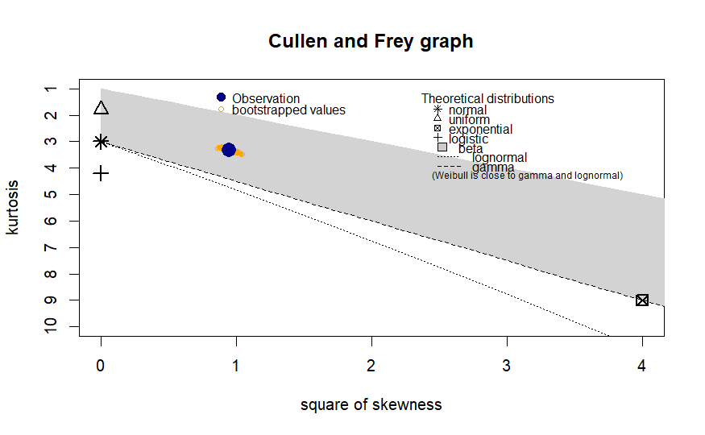

```r
descdist(DfTrain$median_house_value, discrete = FALSE, boot = 1500)
```

Puede verse que la variable dependiente sigue aproximadamente una función beta. Sin embargo, hay valores en la cola de la distribución que la deforman. Estos podrían ser outliers. Esto se evaluará en la sección de filtrado de datos.

También se puede obtener la densidad de los valores de las viviendas dependiendo de la variable categórica:

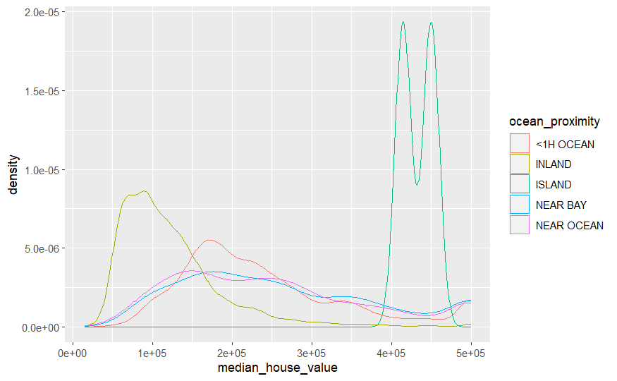

```r
ggplot(data = DfTrain, aes(x = median_house_value, col = ocean_proximity))+
  geom_density(stat =  'density')
```

También se procede a graficar las densidades de todas las variables independientes no categóricas

```r
DfnoCat <- DfTrain %>%
  dplyr :: select(-c(id,median_house_value, ocean_proximity))
```

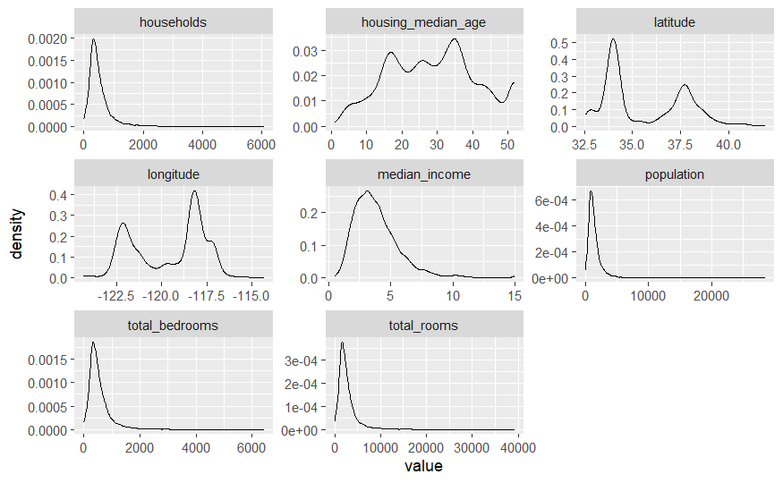

```r
DfnoCatLong <- DfnoCat %>%
  pivot_longer(colnames(DfnoCat)) %>%
  as.data.frame()

ggplot(data = DfnoCatLong, aes(x = value))+
  geom_density()+
  facet_wrap(~name, scales = 'free')
```

Se observa que les densidades de *households*, *population*, *median_income*, *total_bedrooms*, y *total_rooms* son bastante similares. El restante de las variables no muestra alguna densidad que pueda catalogarse.

### Correlación entre variables

Siempre es una buena práctica obtener el índice de correlación entre las variables. Este se hará mediante un mapa de correlación. Se excluye la variable *ocean_proximity* por ser categórica

```r
DCor <- DfTrain %>%
  dplyr:: select(-ocean_proximity)
```

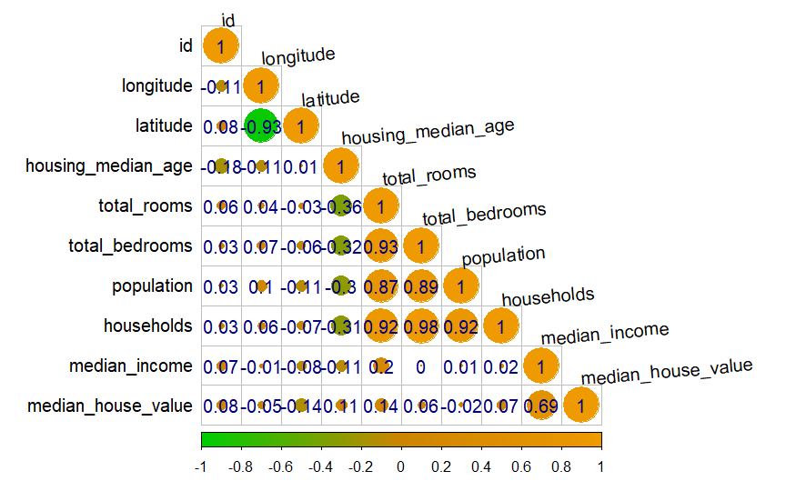

```r
DCor <- na.omit(DCor)
pallete <- colorRampPalette(c('green3', 'orange3', 'orange2'))(50)
corrplot(cor(DCor), p.mat =cor(DCor), type = 'lower', tl.srt = 5, tl.col = 'black',
        col.lim = c(-1,1), col = pallete, insig = "p-value", sig.level = -1, pch.col = 'navyblue')
```

Puede observarse que, de todas las variables, únicamente *median_income* tiene una relación más o menos lineal con *median_house_value*, aunque esta tampoco es muy fuerte al tener un coeficiente de correlación de 0.69. Para observar mejor esto, se procede a realizar un scatterplot de ambas variables:

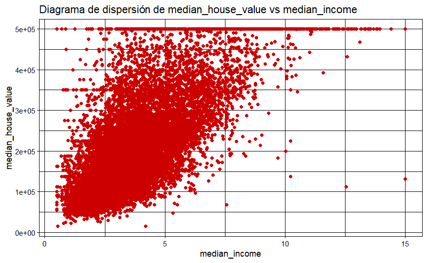

```r
ggplot(data = DfTrain, aes(x = median_income, y = median_house_value))+
  geom_point(col = 'red3') +
  theme_linedraw()+ ggtitle('Diagrama de dispersión de median_house_value vs median_income')
```

Fácilmente se nota que hay datos que son aproximadamente constantes en *median_house_value* = 500000. Estos son los datos que se ven en los análisis previos que alteran la forma de la distribución de la variable, y que posiblemente puedan ser outliers.

## Limpieza de datos

### Cambio de categórica

Lo primero a realizar será el cambio de variable categórica a numérica

```r
DfTrainC <- DfTrain
```

```r
DfTrainC <- dummy_cols(DfTrainC, select_columns = "ocean_proximity")
DfTrainC <- DfTrainC %>%
  dplyr :: select(-ocean_proximity)
```

```r
DfTrainC <- DfTrainC %>%
  rename(ocean_proximity_NEAR_OCEAN = `ocean_proximity_NEAR OCEAN`,
         ocean_proximity_NEAR_BAY = `ocean_proximity_NEAR BAY`,
         `ocean_proximity_1H_OCEAN` = `ocean_proximity_<1H OCEAN`
         )
```

```r
DfTrainC
```

| id | longitude | latitude | housing_median_age | total_rooms | total_bedrooms | population | households | median_income | median_house_value | ocean_proximity_1H_OCEAN | ocean_proximity_INLAND | ocean_proximity_ISLAND | ocean_proximity_NEAR_BAY | ocean_proximity_NEAR_OCEAN |
| --- | --- | --- | --- | --- | --- | --- | --- | --- | --- | --- | --- | --- | --- | --- |
| 9744 | -121.65 | 36.77 | 15 | 2191 | 358 | 1150 | 330 | 4.7969 | 227500 | 1 | 0 | 0 | 0 | 0 |
| 13893 | -116.27 | 34.13 | 37 | 452 | 109 | 184 | 59 | 3.7292 | 65800 | 0 | 1 | 0 | 0 | 0 |
| 18277 | -122.07 | 37.34 | 35 | 1172 | 184 | 512 | 175 | 7.3561 | 500001 | 1 | 0 | 0 | 0 | 0 |
| 16176 | -122.39 | 37.74 | 52 | 126 | 24 | 37 | 27 | 10.2264 | 225000 | 0 | 0 | 0 | 1 | 0 |
| 8843 | -118.38 | 34.09 | 28 | 4001 | 1352 | 1799 | 1220 | 2.5784 | 272900 | 1 | 0 | 0 | 0 | 0 |
| 7653 | -118.27 | 33.83 | 28 | 2152 | 415 | 1623 | 429 | 4.3500 | 200500 | 1 | 0 | 0 | 0 | 0 |
| 14056 | -117.13 | 32.75 | 23 | 3999 | 1182 | 2051 | 1130 | 2.1292 | 135000 | 0 | 0 | 0 | 0 | 1 |
| 18819 | -120.24 | 39.67 | 40 | 690 | 129 | 305 | 110 | 2.3625 | 62500 | 0 | 1 | 0 | 0 | 0 |
| 17145 | -122.19 | 37.45 | 18 | 1636 | 414 | 853 | 439 | 5.1032 | 464600 | 0 | 0 | 0 | 0 | 1 |
| 16187 | -121.29 | 37.95 | 52 | 107 | 79 | 167 | 53 | 0.7917 | 22500 | 0 | 1 | 0 | 0 | 0 |

[output cut: 990 more lines]

### Tratamiento de Outliers

Ya que la medida de efectividad del modelo es el RMSE, se sabe que este es susceptible a los errores cuando estos son grandes. Para manejar esto, se introducirá ruido en las variables de valor alto, el cual correrá el modelo hacia la derecha.

```r
DfTrainC <-  DfTrainC%>%
  mutate(median_house_value = ifelse(median_house_value >=500000, median_house_value+200000 ,median_house_value))
```

### Eliminación de NAs

La primera y más sencilla es eliminar los valores *NA* del dataset

```r
TrainNoNa <- na.omit(DfTrainC)
```

### Imputación de NAs

#### Imputación de medianas

La aproximación que se utilizará es sustituir el valor *NA* por la mediana de la distribución

```r
TrainMedian <- DfTrainC
```

```r
TrainMedian$total_bedrooms <- ifelse(is.na(TrainMedian$total_bedrooms),
                                  median(TrainMedian$total_bedrooms, na.rm = TRUE),
                                  TrainMedian$total_bedrooms)
```

Para ver la diferencia en los datos, se grafican las densidades con *NA* y con la sustitución de la mediana

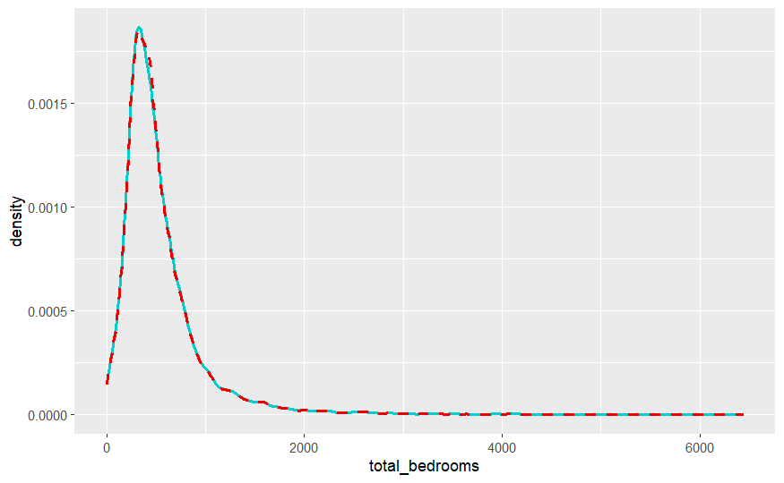

```r
ggplot(data = TrainNoNa, aes(x = total_bedrooms))+
  geom_density(stat = 'density', col = 'cyan3', lwd = 1) +
  geom_density(data = TrainMedian, aes(x = total_bedrooms, y = ..density..), col = 'red2', lwd = 1, linetype = 'dashed')
```

Puede notarse que ambas densidades son extremadamente similares.

#### Imputación de medias

Como una alternativa, se imputa la media

```r
TrainMean <- DfTrainC
```

```r
TrainMean$total_bedrooms <- ifelse(is.na(TrainMean$total_bedrooms),
                                  mean(TrainMean$total_bedrooms, na.rm = TRUE),
                                  TrainMean$total_bedrooms)
```

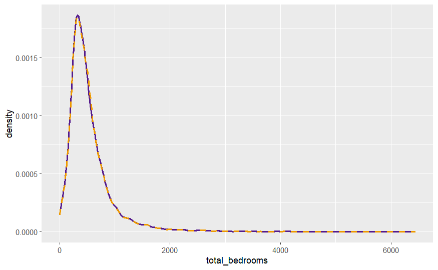

```r
ggplot(data = TrainNoNa, aes(x = total_bedrooms))+
  geom_density(stat = 'density', col = 'purple4', lwd = 1) +
  geom_density(data = TrainMean, aes(x = total_bedrooms, y = ..density..), col = 'orange2', lwd = 1, linetype = 'dashed')
```

### Uniformidad de dimensionales

Para tratar la uniformidad de las dimensionales, creará un dataset donde se dividirán las variables *total_bedrooms*, *population* y *total_rooms* entre la variable *households* para hacer más dimensionalmente uniforme el dataset. Se hará este procedimiento tanto con el dataset obtenido borrando los Na y con el que se sustituyó por la mediana.

```r
### Set con los NA anulados
TrainUNoNa <- TrainNoNa
```

```r
TrainUNoNa$population <- TrainUNoNa$population/TrainUNoNa$households
TrainUNoNa$total_bedrooms <- TrainUNoNa$total_bedrooms/TrainUNoNa$households
TrainUNoNa$total_rooms <- TrainUNoNa$total_rooms/TrainUNoNa$households
```

```r
head(TrainUNoNa)
```

|  | id | longitude | latitude | housing_median_age | total_rooms | total_bedrooms | population | households | median_income | median_house_value | ocean_proximity_1H_OCEAN | ocean_proximity_INLAND | ocean_proximity_ISLAND | ocean_proximity_NEAR_BAY | ocean_proximity_NEAR_OCEAN |
| --- | --- | --- | --- | --- | --- | --- | --- | --- | --- | --- | --- | --- | --- | --- | --- |
| 1 | 9744 | -121.65 | 36.77 | 15 | 6.639394 | 1.0848485 | 3.484848 | 330 | 4.7969 | 227500 | 1 | 0 | 0 | 0 | 0 |
| 2 | 13893 | -116.27 | 34.13 | 37 | 7.661017 | 1.8474576 | 3.118644 | 59 | 3.7292 | 65800 | 0 | 1 | 0 | 0 | 0 |
| 3 | 18277 | -122.07 | 37.34 | 35 | 6.697143 | 1.0514286 | 2.925714 | 175 | 7.3561 | 700001 | 1 | 0 | 0 | 0 | 0 |
| 4 | 16176 | -122.39 | 37.74 | 52 | 4.666667 | 0.8888889 | 1.370370 | 27 | 10.2264 | 225000 | 0 | 0 | 0 | 1 | 0 |
| 5 | 8843 | -118.38 | 34.09 | 28 | 3.279508 | 1.1081967 | 1.474590 | 1220 | 2.5784 | 272900 | 1 | 0 | 0 | 0 | 0 |
| 6 | 7653 | -118.27 | 33.83 | 28 | 5.016317 | 0.9673660 | 3.783217 | 429 | 4.3500 | 200500 | 1 | 0 | 0 | 0 | 0 |

```r
### Set con medianas agregadas

TrainUMedian <- TrainMedian
```

```r
TrainUMedian$population <- TrainUMedian$population/TrainUMedian$households
TrainUMedian$total_bedrooms <- TrainUMedian$total_bedrooms/TrainUMedian$households
TrainUMedian$total_rooms <- TrainUMedian$total_rooms/TrainUMedian$households
```

```r
head(TrainUMedian)
```

|  | id | longitude | latitude | housing_median_age | total_rooms | total_bedrooms | population | households | median_income | median_house_value | ocean_proximity_1H_OCEAN | ocean_proximity_INLAND | ocean_proximity_ISLAND | ocean_proximity_NEAR_BAY | ocean_proximity_NEAR_OCEAN |
| --- | --- | --- | --- | --- | --- | --- | --- | --- | --- | --- | --- | --- | --- | --- | --- |
| 1 | 9744 | -121.65 | 36.77 | 15 | 6.639394 | 1.0848485 | 3.484848 | 330 | 4.7969 | 227500 | 1 | 0 | 0 | 0 | 0 |
| 2 | 13893 | -116.27 | 34.13 | 37 | 7.661017 | 1.8474576 | 3.118644 | 59 | 3.7292 | 65800 | 0 | 1 | 0 | 0 | 0 |
| 3 | 18277 | -122.07 | 37.34 | 35 | 6.697143 | 1.0514286 | 2.925714 | 175 | 7.3561 | 700001 | 1 | 0 | 0 | 0 | 0 |
| 4 | 16176 | -122.39 | 37.74 | 52 | 4.666667 | 0.8888889 | 1.370370 | 27 | 10.2264 | 225000 | 0 | 0 | 0 | 1 | 0 |
| 5 | 8843 | -118.38 | 34.09 | 28 | 3.279508 | 1.1081967 | 1.474590 | 1220 | 2.5784 | 272900 | 1 | 0 | 0 | 0 | 0 |
| 6 | 7653 | -118.27 | 33.83 | 28 | 5.016317 | 0.9673660 | 3.783217 | 429 | 4.3500 | 200500 | 1 | 0 | 0 | 0 | 0 |

```r
### Set con media imputada
TrainUMean <- TrainMean
```

```r
TrainUMean$population <- TrainUMean$population/TrainUMean$households
TrainUMean$total_bedrooms <- TrainUMean$total_bedrooms/TrainUMean$households
TrainUMean$total_rooms <- TrainUMean$total_rooms/TrainUMean$households
```

```r
head(TrainUMean)
```

|  | id | longitude | latitude | housing_median_age | total_rooms | total_bedrooms | population | households | median_income | median_house_value | ocean_proximity_1H_OCEAN | ocean_proximity_INLAND | ocean_proximity_ISLAND | ocean_proximity_NEAR_BAY | ocean_proximity_NEAR_OCEAN |
| --- | --- | --- | --- | --- | --- | --- | --- | --- | --- | --- | --- | --- | --- | --- | --- |
| 1 | 9744 | -121.65 | 36.77 | 15 | 6.639394 | 1.0848485 | 3.484848 | 330 | 4.7969 | 227500 | 1 | 0 | 0 | 0 | 0 |
| 2 | 13893 | -116.27 | 34.13 | 37 | 7.661017 | 1.8474576 | 3.118644 | 59 | 3.7292 | 65800 | 0 | 1 | 0 | 0 | 0 |
| 3 | 18277 | -122.07 | 37.34 | 35 | 6.697143 | 1.0514286 | 2.925714 | 175 | 7.3561 | 700001 | 1 | 0 | 0 | 0 | 0 |
| 4 | 16176 | -122.39 | 37.74 | 52 | 4.666667 | 0.8888889 | 1.370370 | 27 | 10.2264 | 225000 | 0 | 0 | 0 | 1 | 0 |
| 5 | 8843 | -118.38 | 34.09 | 28 | 3.279508 | 1.1081967 | 1.474590 | 1220 | 2.5784 | 272900 | 1 | 0 | 0 | 0 | 0 |
| 6 | 7653 | -118.27 | 33.83 | 28 | 5.016317 | 0.9673660 | 3.783217 | 429 | 4.3500 | 200500 | 1 | 0 | 0 | 0 | 0 |

```r
colnames(TrainMedian)
```

```
 [1] "id"                         "longitude"                  "latitude"
 [4] "housing_median_age"         "total_rooms"                "total_bedrooms"
 [7] "population"                 "households"                 "median_income"
[10] "median_house_value"         "ocean_proximity_1H_OCEAN"   "ocean_proximity_INLAND"
[13] "ocean_proximity_ISLAND"     "ocean_proximity_NEAR_BAY"   "ocean_proximity_NEAR_OCEAN"
```

### Estandarización de los datos

```r
### Estandarizando el dataset solo con NA omitidos
TrainSNoNa <- subset(TrainNoNa,select=c(longitude, latitude, housing_median_age, total_rooms, total_bedrooms, population, households, median_income))
```

```r
## Obteniendo la media y desviación de las variables a estandarizar
MeansNoNa <- colMeans(TrainSNoNa)
SdNoNa <- sapply(TrainSNoNa,sd)
```

```r
TrainSNoNa <- data.frame(scale(TrainSNoNa))
```

```r
head(TrainSNoNa)
```

|  | longitude | latitude | housing_median_age | total_rooms | total_bedrooms | population | households | median_income |
| --- | --- | --- | --- | --- | --- | --- | --- | --- |
| 1 | -1.0337144 | 0.5283127 | -1.10020186 | -0.2001830 | -0.4239941 | -0.2440160 | -0.4401416 | 0.49274230 |
| 2 | 1.6518627 | -0.7079080 | 0.64734507 | -0.9840177 | -1.0112411 | -1.1039068 | -1.1424472 | -0.07119318 |
| 3 | -1.2433691 | 0.7952239 | 0.48847717 | -0.6594858 | -0.8343595 | -0.8119356 | -0.8418293 | 1.84445503 |
| 4 | -1.4031061 | 0.9825301 | 1.83885434 | -1.1309585 | -1.2117069 | -1.2347598 | -1.2253763 | 3.36048388 |
| 5 | 0.5985973 | -0.7266386 | -0.06756049 | 0.6156542 | 1.9202770 | 0.3336953 | 1.8663232 | -0.67902024 |
| 6 | 0.6535069 | -0.8483876 | -0.06756049 | -0.2177618 | -0.2895641 | 0.1770279 | -0.1835798 | 0.25669962 |

```r
TrainSNoNa <- cbind(id = TrainNoNa$id,TrainSNoNa,median_house_value = TrainNoNa$median_house_value, ocean_proximity_1H_OCEAN = TrainNoNa$ocean_proximity_1H_OCEAN,ocean_proximity_INLAND = TrainNoNa$ocean_proximity_INLAND, ocean_proximity_ISLAND = TrainNoNa$ocean_proximity_ISLAND, ocean_proximity_NEAR_BAY = TrainNoNa$ocean_proximity_NEAR_BAY, ocean_proximity_NEAR_OCEAN = TrainNoNa$ocean_proximity_NEAR_OCEAN)
```

```r
head(TrainSNoNa)
```

|  | id | longitude | latitude | housing_median_age | total_rooms | total_bedrooms | population | households | median_income | median_house_value | ocean_proximity_1H_OCEAN | ocean_proximity_INLAND | ocean_proximity_ISLAND | ocean_proximity_NEAR_BAY | ocean_proximity_NEAR_OCEAN |
| --- | --- | --- | --- | --- | --- | --- | --- | --- | --- | --- | --- | --- | --- | --- | --- |
| 1 | 9744 | -1.0337144 | 0.5283127 | -1.10020186 | -0.2001830 | -0.4239941 | -0.2440160 | -0.4401416 | 0.49274230 | 227500 | 1 | 0 | 0 | 0 | 0 |
| 2 | 13893 | 1.6518627 | -0.7079080 | 0.64734507 | -0.9840177 | -1.0112411 | -1.1039068 | -1.1424472 | -0.07119318 | 65800 | 0 | 1 | 0 | 0 | 0 |
| 3 | 18277 | -1.2433691 | 0.7952239 | 0.48847717 | -0.6594858 | -0.8343595 | -0.8119356 | -0.8418293 | 1.84445503 | 700001 | 1 | 0 | 0 | 0 | 0 |
| 4 | 16176 | -1.4031061 | 0.9825301 | 1.83885434 | -1.1309585 | -1.2117069 | -1.2347598 | -1.2253763 | 3.36048388 | 225000 | 0 | 0 | 0 | 1 | 0 |
| 5 | 8843 | 0.5985973 | -0.7266386 | -0.06756049 | 0.6156542 | 1.9202770 | 0.3336953 | 1.8663232 | -0.67902024 | 272900 | 1 | 0 | 0 | 0 | 0 |
| 6 | 7653 | 0.6535069 | -0.8483876 | -0.06756049 | -0.2177618 | -0.2895641 | 0.1770279 | -0.1835798 | 0.25669962 | 200500 | 1 | 0 | 0 | 0 | 0 |

```r
### Estandarizando el dataset solo con mediana imputada
TrainSMedian <- subset(TrainMedian,select=c(longitude, latitude, housing_median_age, total_rooms, total_bedrooms, population, households, median_income))
```

```r
### Media y varianza de variables a estandarizar
MeansMedian <- colMeans(TrainSMedian)
SDMedian <- sapply(TrainSMedian, sd)
```

```r
TrainSMedian <- data.frame(scale(TrainSMedian))
```

```r
TrainSMedian <- cbind(id = TrainMedian$id,TrainSMedian,median_house_value = TrainMedian$median_house_value, ocean_proximity_1H_OCEAN = TrainMedian$ocean_proximity_1H_OCEAN, ocean_proximity_INLAND = TrainMedian$ocean_proximity_INLAND, ocean_proximity_ISLAND = TrainMedian$ocean_proximity_ISLAND, ocean_proximity_NEAR_BAY = TrainMedian$ocean_proximity_NEAR_BAY, ocean_proximity_NEAR_OCEAN = TrainMedian$ocean_proximity_NEAR_OCEAN)
```

```r
head(TrainSMedian)
```

|  | id | longitude | latitude | housing_median_age | total_rooms | total_bedrooms | population | households | median_income | median_house_value | ocean_proximity_1H_OCEAN | ocean_proximity_INLAND | ocean_proximity_ISLAND | ocean_proximity_NEAR_BAY | ocean_proximity_NEAR_OCEAN |
| --- | --- | --- | --- | --- | --- | --- | --- | --- | --- | --- | --- | --- | --- | --- | --- |
| 1 | 9744 | -1.0329753 | 0.5282017 | -1.10013447 | -0.2005554 | -0.4235418 | -0.2448725 | -0.4405094 | 0.49286352 | 227500 | 1 | 0 | 0 | 0 | 0 |
| 2 | 13893 | 1.6523101 | -0.7080277 | 0.64794771 | -0.9855557 | -1.0134226 | -1.1045070 | -1.1422511 | -0.07118585 | 65800 | 0 | 1 | 0 | 0 | 0 |
| 3 | 18277 | -1.2426072 | 0.7951149 | 0.48903115 | -0.6605412 | -0.8357477 | -0.8126228 | -0.8418746 | 1.84484924 | 700001 | 1 | 0 | 0 | 0 | 0 |
| 4 | 16176 | -1.4023268 | 0.9824224 | 1.83982193 | -1.1327150 | -1.2147875 | -1.2353209 | -1.2251136 | 3.36118426 | 225000 | 0 | 0 | 0 | 1 | 0 |
| 5 | 8843 | 0.5991592 | -0.7267584 | -0.06717681 | 0.6164949 | 1.9312432 | 0.3326666 | 1.8641038 | -0.67913567 | 272900 | 1 | 0 | 0 | 0 | 0 |
| 6 | 7653 | 0.6540628 | -0.8485083 | -0.06717681 | -0.2181604 | -0.2885089 | 0.1760458 | -0.1841535 | 0.25677317 | 200500 | 1 | 0 | 0 | 0 | 0 |

```r
### Estandarizando el dataset solo con imputación de media
TrainSMean <- subset(TrainMean,select=c(longitude, latitude, housing_median_age, total_rooms, total_bedrooms, population, households, median_income))
```

```r
### Media y varianza de variables a estandarizar
MeansMean <- colMeans(TrainSMean)
SDMean <- sapply(TrainSMean, sd)
```

```r
TrainSMean <- data.frame(scale(TrainSMean))
```

```r
TrainSMean <- cbind(id = TrainMean$id,TrainSMean,median_house_value = TrainMean$median_house_value, ocean_proximity_1H_OCEAN = TrainMean$ocean_proximity_1H_OCEAN, ocean_proximity_INLAND = TrainMean$ocean_proximity_INLAND, ocean_proximity_ISLAND = TrainMean$ocean_proximity_ISLAND, ocean_proximity_NEAR_BAY = TrainMean$ocean_proximity_NEAR_BAY, ocean_proximity_NEAR_OCEAN = TrainMean$ocean_proximity_NEAR_OCEAN)
```

```r
head(TrainSMean)
```

|  | id | longitude | latitude | housing_median_age | total_rooms | total_bedrooms | population | households | median_income | median_house_value | ocean_proximity_1H_OCEAN | ocean_proximity_INLAND | ocean_proximity_ISLAND | ocean_proximity_NEAR_BAY | ocean_proximity_NEAR_OCEAN |
| --- | --- | --- | --- | --- | --- | --- | --- | --- | --- | --- | --- | --- | --- | --- | --- |
| 1 | 9744 | -1.0329753 | 0.5282017 | -1.10013447 | -0.2005554 | -0.4260190 | -0.2448725 | -0.4405094 | 0.49286352 | 227500 | 1 | 0 | 0 | 0 | 0 |
| 2 | 13893 | 1.6523101 | -0.7080277 | 0.64794771 | -0.9855557 | -1.0160706 | -1.1045070 | -1.1422511 | -0.07118585 | 65800 | 0 | 1 | 0 | 0 | 0 |
| 3 | 18277 | -1.2426072 | 0.7951149 | 0.48903115 | -0.6605412 | -0.8383442 | -0.8126228 | -0.8418746 | 1.84484924 | 700001 | 1 | 0 | 0 | 0 | 0 |
| 4 | 16176 | -1.4023268 | 0.9824224 | 1.83982193 | -1.1327150 | -1.2174938 | -1.2353209 | -1.2251136 | 3.36118426 | 225000 | 0 | 0 | 0 | 1 | 0 |
| 5 | 8843 | 0.5991592 | -0.7267584 | -0.06717681 | 0.6164949 | 1.9294478 | 0.3326666 | 1.8641038 | -0.67913567 | 272900 | 1 | 0 | 0 | 0 | 0 |
| 6 | 7653 | 0.6540628 | -0.8485083 | -0.06717681 | -0.2181604 | -0.2909470 | 0.1760458 | -0.1841535 | 0.25677317 | 200500 | 1 | 0 | 0 | 0 | 0 |

```r
### Estandarizando el dataset sin Na y uniforme
TrainSUNoNa <- subset(TrainUNoNa,select=c(longitude, latitude, housing_median_age, total_rooms, total_bedrooms, population, households, median_income))
```

```r
### Media y varianza de variables a estandarizar
MeansUNoNa <- colMeans(TrainSUNoNa)
SDUNoNa <- sapply(TrainSUNoNa, sd)
```

```r
TrainSUNoNa <- data.frame(scale(TrainSUNoNa))
```

```r
TrainSUNoNa <- cbind(id = TrainUNoNa$id,TrainSUNoNa,median_house_value = TrainUNoNa$median_house_value, ocean_proximity_1H_OCEAN = TrainUNoNa$ocean_proximity_1H_OCEAN, ocean_proximity_INLAND = TrainUNoNa$ocean_proximity_INLAND, ocean_proximity_ISLAND = TrainUNoNa$ocean_proximity_ISLAND, ocean_proximity_NEAR_BAY = TrainUNoNa$ocean_proximity_NEAR_BAY, ocean_proximity_NEAR_OCEAN = TrainUNoNa$ocean_proximity_NEAR_OCEAN)
```

```r
head(TrainSUNoNa)
```

|  | id | longitude | latitude | housing_median_age | total_rooms | total_bedrooms | population | households | median_income | median_house_value | ocean_proximity_1H_OCEAN | ocean_proximity_INLAND | ocean_proximity_ISLAND | ocean_proximity_NEAR_BAY | ocean_proximity_NEAR_OCEAN |
| --- | --- | --- | --- | --- | --- | --- | --- | --- | --- | --- | --- | --- | --- | --- | --- |
| 1 | 9744 | -1.0337144 | 0.5283127 | -1.10020186 | 0.5257733 | -0.02111643 | 0.0298357545 | -0.4401416 | 0.49274230 | 227500 | 1 | 0 | 0 | 0 | 0 |
| 2 | 13893 | 1.6518627 | -0.7079080 | 0.64734507 | 0.9633337 | 1.60139714 | 0.0003683018 | -1.1424472 | -0.07119318 | 65800 | 0 | 1 | 0 | 0 | 0 |
| 3 | 18277 | -1.2433691 | 0.7952239 | 0.48847717 | 0.5505071 | -0.09222004 | -0.0151562222 | -0.8418293 | 1.84445503 | 700001 | 1 | 0 | 0 | 0 | 0 |
| 4 | 16176 | -1.4031061 | 0.9825301 | 1.83885434 | -0.3191444 | -0.43803656 | -0.1403104291 | -1.2253763 | 3.36048388 | 225000 | 0 | 0 | 0 | 1 | 0 |
| 5 | 8843 | 0.5985973 | -0.7266386 | -0.06756049 | -0.9132634 | 0.02855886 | -0.1319241517 | 1.8663232 | -0.67902024 | 272900 | 1 | 0 | 0 | 0 | 0 |
| 6 | 7653 | 0.6535069 | -0.8483876 | -0.06756049 | -0.1693894 | -0.27107014 | 0.0538446232 | -0.1835798 | 0.25669962 | 200500 | 1 | 0 | 0 | 0 | 0 |

```r
### Estandarizando el dataset con mediana agregada y uniforme
TrainSUMedian <- subset(TrainUMedian,select=c(longitude, latitude, housing_median_age, total_rooms, total_bedrooms, population, households, median_income))
```

```r
### Media y varianza de variables a estandarizar
MeansUMedian <- colMeans(TrainSUMedian)
SDUMedian <- sapply(TrainSUMedian, sd)
```

```r
TrainSUMedian <- data.frame(scale(TrainSUMedian))
```

```r
TrainSUMedian <- cbind(id = TrainUMedian$id,TrainSUMedian,median_house_value = TrainUMedian$median_house_value, ocean_proximity_1H_OCEAN = TrainUMedian$ocean_proximity_1H_OCEAN, ocean_proximity_INLAND = TrainUMedian$ocean_proximity_INLAND, ocean_proximity_ISLAND = TrainUMedian$ocean_proximity_ISLAND, ocean_proximity_NEAR_BAY = TrainUMedian$ocean_proximity_NEAR_BAY, ocean_proximity_NEAR_OCEAN = TrainUMedian$ocean_proximity_NEAR_OCEAN)
```

```r
head(TrainSUMedian)
```

|  | id | longitude | latitude | housing_median_age | total_rooms | total_bedrooms | population | households | median_income | median_house_value | ocean_proximity_1H_OCEAN | ocean_proximity_INLAND | ocean_proximity_ISLAND | ocean_proximity_NEAR_BAY | ocean_proximity_NEAR_OCEAN |
| --- | --- | --- | --- | --- | --- | --- | --- | --- | --- | --- | --- | --- | --- | --- | --- |
| 1 | 9744 | -1.0329753 | 0.5282017 | -1.10013447 | 0.5279465 | -0.02624518 | 0.0300895838 | -0.4405094 | 0.49286352 | 227500 | 1 | 0 | 0 | 0 | 0 |
| 2 | 13893 | 1.6523101 | -0.7080277 | 0.64794771 | 0.9668225 | 1.42120150 | 0.0004818684 | -1.1422511 | -0.07118585 | 65800 | 0 | 1 | 0 | 0 | 0 |
| 3 | 18277 | -1.2426072 | 0.7951149 | 0.48903115 | 0.5527547 | -0.08967682 | -0.0151165510 | -0.8418746 | 1.84484924 | 700001 | 1 | 0 | 0 | 0 | 0 |
| 4 | 16176 | -1.4023268 | 0.9824224 | 1.83982193 | -0.3195116 | -0.39818023 | -0.1408664816 | -1.2251136 | 3.36118426 | 225000 | 0 | 0 | 0 | 1 | 0 |
| 5 | 8843 | 0.5991592 | -0.7267584 | -0.06717681 | -0.9154170 | 0.01807021 | -0.1324402861 | 1.8641038 | -0.67913567 | 272900 | 1 | 0 | 0 | 0 | 0 |
| 6 | 7653 | 0.6540628 | -0.8485083 | -0.06717681 | -0.1693064 | -0.24922924 | 0.0542127327 | -0.1841535 | 0.25677317 | 200500 | 1 | 0 | 0 | 0 | 0 |

```r
### Estandarizando el dataset con mediana agregada y uniforme
TrainSUMean <- subset(TrainUMean,select=c(longitude, latitude, housing_median_age, total_rooms, total_bedrooms, population, households, median_income))
```

```r
### Media y varianza de variables a estandarizar
MeansUMean <- colMeans(TrainSUMean)
SDUMean <- sapply(TrainSUMean, sd)
```

```r
TrainSUMean <- data.frame(scale(TrainSUMean))
```

```r
TrainSUMean <- cbind(id = TrainUMean$id,TrainSUMean,median_house_value = TrainUMean$median_house_value, ocean_proximity_1H_OCEAN = TrainUMean$ocean_proximity_1H_OCEAN, ocean_proximity_INLAND = TrainUMean$ocean_proximity_INLAND, ocean_proximity_ISLAND = TrainUMean$ocean_proximity_ISLAND, ocean_proximity_NEAR_BAY = TrainUMean$ocean_proximity_NEAR_BAY, ocean_proximity_NEAR_OCEAN = TrainUMean$ocean_proximity_NEAR_OCEAN)
```

```r
head(TrainSUMean)
```

|  | id | longitude | latitude | housing_median_age | total_rooms | total_bedrooms | population | households | median_income | median_house_value | ocean_proximity_1H_OCEAN | ocean_proximity_INLAND | ocean_proximity_ISLAND | ocean_proximity_NEAR_BAY | ocean_proximity_NEAR_OCEAN |
| --- | --- | --- | --- | --- | --- | --- | --- | --- | --- | --- | --- | --- | --- | --- | --- |
| 1 | 9744 | -1.0329753 | 0.5282017 | -1.10013447 | 0.5279465 | -0.03091046 | 0.0300895838 | -0.4405094 | 0.49286352 | 227500 | 1 | 0 | 0 | 0 | 0 |
| 2 | 13893 | 1.6523101 | -0.7080277 | 0.64794771 | 0.9668225 | 1.33291147 | 0.0004818684 | -1.1422511 | -0.07118585 | 65800 | 0 | 1 | 0 | 0 | 0 |
| 3 | 18277 | -1.2426072 | 0.7951149 | 0.48903115 | 0.5527547 | -0.09067740 | -0.0151165510 | -0.8418746 | 1.84484924 | 700001 | 1 | 0 | 0 | 0 | 0 |
| 4 | 16176 | -1.4023268 | 0.9824224 | 1.83982193 | -0.3195116 | -0.38135734 | -0.1408664816 | -1.2251136 | 3.36118426 | 225000 | 0 | 0 | 0 | 1 | 0 |
| 5 | 8843 | 0.5991592 | -0.7267584 | -0.06717681 | -0.9154170 | 0.01084466 | -0.1324402861 | 1.8641038 | -0.67913567 | 272900 | 1 | 0 | 0 | 0 | 0 |
| 6 | 7653 | 0.6540628 | -0.8485083 | -0.06717681 | -0.1693064 | -0.24101184 | 0.0542127327 | -0.1841535 | 0.25677317 | 200500 | 1 | 0 | 0 | 0 | 0 |

Finalmente, se tiene un conjunto de datasets que pueden ser utilizdos para pruebas, los cuales son:

- **TrainNoNa:** Dataset con los Na omitidos.
- **TrainMedian:** Dataset con los Na sustituidos por la mediana de la distribución.
- **TrainMean:** Dataset con la media imputada
- **TrainUNoNa:** Dataset con las dimensionales uniformes y con los Na omitidos.
- **TrainUMedian:** Dataset con las dimensionales uniformes y con los Na sustituidos por la mediana de la distribución.
- **TrainUMean:** Dataset con las dimensionales uniformes y con la media imputada
- **TrainSNoNa:** Dataset estandarizado con los Na omitidos.
- **TrainSMedian:** Dataset estandarizado con los Na sustituidos por la mediana de la distribución.
- **TrainSMean:** Dataset estandarizado con la media imputada
- **TrainSUNoNa:** Dataset estandarizado, con dimensionales uniformes y con los Na omitidos.
- **TrainSUMedian:** Dataset estandarizao, con dimensionales uniformes y con los Na sustituidos por la mediana de la distribución.
- **TrainSUMean:** Dataset estandarizado, con dimensionles uniformes y con la media imputada

## Prueba de modelos

Antes de iniciar con la prueba de los modelos, es necesario acomodar el set de pruebas

### Tratamiento set de pruebas

```r
str(DfTest)
```

```
'data.frame':   6193 obs. of  10 variables:
 $ id                : int  19109 17007 1229 18154 20519 4499 16552 5303 7573 6412 ...
 $ longitude         : num  -123 -122 -120 -122 -122 ...
 $ latitude          : num  38.2 37.5 38.4 37.4 38.6 ...
 $ housing_median_age: int  45 37 18 34 32 26 14 46 42 36 ...
 $ total_rooms       : int  1615 991 2912 2400 2070 745 1847 1302 1739 1471 ...
 $ total_bedrooms    : int  338 180 663 419 561 258 325 215 370 246 ...
 $ population        : int  823 463 999 1017 2046 694 1030 482 1104 751 ...
 $ households        : int  327 177 411 384 523 236 309 226 297 230 ...
 $ median_income     : num  2.52 5.17 2.73 4.14 1.94 ...
 $ ocean_proximity   : chr  "<1H OCEAN" "NEAR OCEAN" "INLAND" "<1H OCEAN" ...
```

```r
summary(DfTest)
```

```
       id          longitude         latitude     housing_median_age  total_rooms    total_bedrooms
 Min.   :    5   Min.   :-124.3   Min.   :32.55   Min.   : 2.00      Min.   :    2   Min.   :   2.0
 1st Qu.: 5215   1st Qu.:-121.8   1st Qu.:33.93   1st Qu.:18.00      1st Qu.: 1446   1st Qu.: 296.0
 Median :10345   Median :-118.5   Median :34.24   Median :29.00      Median : 2118   Median : 434.0
 Mean   :10305   Mean   :-119.5   Mean   :35.61   Mean   :28.54      Mean   : 2584   Mean   : 526.8
 3rd Qu.:15422   3rd Qu.:-118.0   3rd Qu.:37.71   3rd Qu.:37.00      3rd Qu.: 3105   3rd Qu.: 635.0
 Max.   :20636   Max.   :-114.6   Max.   :41.95   Max.   :52.00      Max.   :28258   Max.   :4522.0
                                                                                     NA's   :72
   population      households     median_income     ocean_proximity
 Min.   :    3   Min.   :   2.0   Min.   : 0.4999   Length:6193
 1st Qu.:  792   1st Qu.: 279.0   1st Qu.: 2.5658   Class :character
 Median : 1166   Median : 410.0   Median : 3.5417   Mode  :character
 Mean   : 1406   Mean   : 488.4   Mean   : 3.8791
 3rd Qu.: 1720   3rd Qu.: 590.0   3rd Qu.: 4.7813
 Max.   :12427   Max.   :4372.0   Max.   :15.0001
```

```r
describe(DfTest)
```

|  | vars | n | mean | sd | median | trimmed | mad | min | max | range | skew | kurtosis | se |
| --- | --- | --- | --- | --- | --- | --- | --- | --- | --- | --- | --- | --- | --- |
| id | 1 | 6193 | 10304.80 | 5913.73 | 10345.00 | 10303.95 | 7559.78 | 5.00 | 20636.00 | 20631.00 | 0.00 | -1.18 | 75.15 |
| longitude | 2 | 6193 | -119.55 | 1.98 | -118.47 | -119.49 | 1.85 | -124.30 | -114.59 | 9.71 | -0.34 | -1.33 | 0.03 |
| latitude | 3 | 6193 | 35.61 | 2.13 | 34.24 | 35.48 | 1.69 | 32.55 | 41.95 | 9.40 | 0.49 | -1.11 | 0.03 |
| housing_median_age | 4 | 6193 | 28.54 | 12.45 | 29.00 | 28.40 | 13.34 | 2.00 | 52.00 | 50.00 | 0.06 | -0.78 | 0.16 |
| total_rooms | 5 | 6193 | 2584.11 | 2036.58 | 2118.00 | 2270.81 | 1160.88 | 2.00 | 28258.00 | 28256.00 | 3.60 | 23.45 | 25.88 |
| total_bedrooms | 6 | 6121 | 526.83 | 389.82 | 434.00 | 466.91 | 235.73 | 2.00 | 4522.00 | 4520.00 | 2.96 | 15.68 | 4.98 |
| population | 7 | 6193 | 1405.73 | 1033.73 | 1166.00 | 1253.42 | 658.27 | 3.00 | 12427.00 | 12424.00 | 2.96 | 16.26 | 13.14 |
| households | 8 | 6193 | 488.36 | 349.04 | 410.00 | 436.94 | 217.94 | 2.00 | 4372.00 | 4370.00 | 2.83 | 14.86 | 4.44 |
| median_income | 9 | 6193 | 3.88 | 1.90 | 3.54 | 3.67 | 1.59 | 0.50 | 15.00 | 14.50 | 1.60 | 4.65 | 0.02 |
| ocean_proximity* | 10 | 6193 | 2.14 | 1.41 | 2.00 | 1.92 | 1.48 | 1.00 | 5.00 | 4.00 | 1.05 | -0.36 | 0.02 |

Este set no contiene la variable a predecir *median_house_value*, ya que es la solución que debe hallarse y probarse en kaggle.

Puede notarse que, de nuevo, hay *NAs* en la variable *total_bedrooms*, por lo que hay que trabajarlas. También se puede ver que los patrones estadísticos del set de pruebas son muy similares al set de entrenamiento. Esto puede verse mejor mediante las gráficas de densidad.

```r
DfnoCatT <- DfTest %>%
  dplyr :: select(-c(id, ocean_proximity))
```

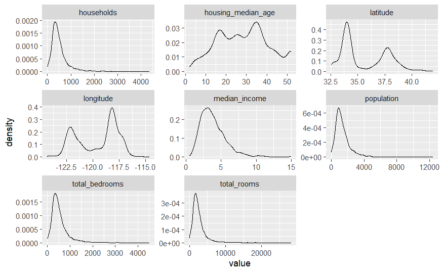

```r
DfnoCatLongT <- DfnoCatT %>%
  pivot_longer(colnames(DfnoCatT)) %>%
  as.data.frame()

ggplot(data = DfnoCatLongT, aes(x = value))+
  geom_density()+
  facet_wrap(~name, scales = 'free')
```

Visualizadas y determinadas las propiedades del set de pruebas, se procede a darle formatos acordes al set de entrneamiento, para que los modelos generados puedan ser validados con su correspondiente set de pruebas en el formato correcto.

#### Cambio de categórica a numérica

Para inicar, se convierte la variable categórica *ocean_proximity* a numérica

```r
DfTestC <- DfTest
```

```r
DfTestC <- dummy_cols(DfTestC, select_columns = "ocean_proximity")
DfTestC <- DfTestC %>%
  dplyr :: select(-ocean_proximity)
```

```r
DfTestC <- DfTestC %>%
  rename(ocean_proximity_NEAR_OCEAN = `ocean_proximity_NEAR OCEAN`,
         ocean_proximity_NEAR_BAY = `ocean_proximity_NEAR BAY`,
         ocean_proximity_1H_OCEAN = `ocean_proximity_<1H OCEAN`
         )
```

```r
head(DfTestC)
```

|  | id | longitude | latitude | housing_median_age | total_rooms | total_bedrooms | population | households | median_income | ocean_proximity_1H_OCEAN | ocean_proximity_INLAND | ocean_proximity_ISLAND | ocean_proximity_NEAR_BAY | ocean_proximity_NEAR_OCEAN |
| --- | --- | --- | --- | --- | --- | --- | --- | --- | --- | --- | --- | --- | --- | --- |
| 1 | 19109 | -122.63 | 38.24 | 45 | 1615 | 338 | 823 | 327 | 2.5179 | 1 | 0 | 0 | 0 | 0 |
| 2 | 17007 | -122.28 | 37.54 | 37 | 991 | 180 | 463 | 177 | 5.1701 | 0 | 0 | 0 | 0 | 1 |
| 3 | 1229 | -120.42 | 38.42 | 18 | 2912 | 663 | 999 | 411 | 2.7344 | 0 | 1 | 0 | 0 | 0 |
| 4 | 18154 | -122.05 | 37.36 | 34 | 2400 | 419 | 1017 | 384 | 4.1369 | 1 | 0 | 0 | 0 | 0 |
| 5 | 20519 | -121.56 | 38.58 | 32 | 2070 | 561 | 2046 | 523 | 1.9426 | 0 | 1 | 0 | 0 | 0 |
| 6 | 4499 | -118.21 | 34.05 | 26 | 745 | 258 | 694 | 236 | 1.3846 | 1 | 0 | 0 | 0 | 0 |

#### Imputando con mediana

```r
### Set con la mediana sustituyendo los NAs
TestMedian <- DfTestC
```

```r
TestMedian$total_bedrooms <- ifelse(is.na(TestMedian$total_bedrooms),
                                  median(TestMedian$total_bedrooms, na.rm = TRUE),
                                  TestMedian$total_bedrooms)
```

#### Imputando con media

```r
### Set con la media sustituyendo los NAs
TestMean <- DfTestC
```

```r
TestMean$total_bedrooms <- ifelse(is.na(TestMean$total_bedrooms),
                                  mean(TestMean$total_bedrooms, na.rm = TRUE),
                                  TestMean$total_bedrooms)
```

#### Corrigiendo dimensionales

Se hace el mismo tratamiento que en el set de entrenamiento para las variables *population*, *total_rooms* y *total_bedrooms*

```r
### Datset con mediana imputada
TestUMedian <- TestMedian
```

```r
TestUMedian$population <- TestUMedian$population/TestUMedian$households
TestUMedian$total_bedrooms <- TestUMedian$total_bedrooms/TestUMedian$households
TestUMedian$total_rooms <- TestUMedian$total_rooms/TestUMedian$households
```

```r
head(TestUMedian)
```

|  | id | longitude | latitude | housing_median_age | total_rooms | total_bedrooms | population | households | median_income | ocean_proximity_1H_OCEAN | ocean_proximity_INLAND | ocean_proximity_ISLAND | ocean_proximity_NEAR_BAY | ocean_proximity_NEAR_OCEAN |
| --- | --- | --- | --- | --- | --- | --- | --- | --- | --- | --- | --- | --- | --- | --- |
| 1 | 19109 | -122.63 | 38.24 | 45 | 4.938838 | 1.033639 | 2.516820 | 327 | 2.5179 | 1 | 0 | 0 | 0 | 0 |
| 2 | 17007 | -122.28 | 37.54 | 37 | 5.598870 | 1.016949 | 2.615819 | 177 | 5.1701 | 0 | 0 | 0 | 0 | 1 |
| 3 | 1229 | -120.42 | 38.42 | 18 | 7.085158 | 1.613139 | 2.430657 | 411 | 2.7344 | 0 | 1 | 0 | 0 | 0 |
| 4 | 18154 | -122.05 | 37.36 | 34 | 6.250000 | 1.091146 | 2.648438 | 384 | 4.1369 | 1 | 0 | 0 | 0 | 0 |
| 5 | 20519 | -121.56 | 38.58 | 32 | 3.957935 | 1.072658 | 3.912046 | 523 | 1.9426 | 0 | 1 | 0 | 0 | 0 |
| 6 | 4499 | -118.21 | 34.05 | 26 | 3.156780 | 1.093220 | 2.940678 | 236 | 1.3846 | 1 | 0 | 0 | 0 | 0 |

```r
### Dataset con media imputada
TestUMean <- TestMean
```

```r
TestUMean$population <- TestUMean$population/TestUMean$households
TestUMean$total_bedrooms <- TestUMean$total_bedrooms/TestUMean$households
TestUMean$total_rooms <- TestUMean$total_rooms/TestUMean$households
```

```r
head(TestUMean)
```

|  | id | longitude | latitude | housing_median_age | total_rooms | total_bedrooms | population | households | median_income | ocean_proximity_1H_OCEAN | ocean_proximity_INLAND | ocean_proximity_ISLAND | ocean_proximity_NEAR_BAY | ocean_proximity_NEAR_OCEAN |
| --- | --- | --- | --- | --- | --- | --- | --- | --- | --- | --- | --- | --- | --- | --- |
| 1 | 19109 | -122.63 | 38.24 | 45 | 4.938838 | 1.033639 | 2.516820 | 327 | 2.5179 | 1 | 0 | 0 | 0 | 0 |
| 2 | 17007 | -122.28 | 37.54 | 37 | 5.598870 | 1.016949 | 2.615819 | 177 | 5.1701 | 0 | 0 | 0 | 0 | 1 |
| 3 | 1229 | -120.42 | 38.42 | 18 | 7.085158 | 1.613139 | 2.430657 | 411 | 2.7344 | 0 | 1 | 0 | 0 | 0 |
| 4 | 18154 | -122.05 | 37.36 | 34 | 6.250000 | 1.091146 | 2.648438 | 384 | 4.1369 | 1 | 0 | 0 | 0 | 0 |
| 5 | 20519 | -121.56 | 38.58 | 32 | 3.957935 | 1.072658 | 3.912046 | 523 | 1.9426 | 0 | 1 | 0 | 0 | 0 |
| 6 | 4499 | -118.21 | 34.05 | 26 | 3.156780 | 1.093220 | 2.940678 | 236 | 1.3846 | 1 | 0 | 0 | 0 | 0 |

#### Estandarizando

Se procede a estandarizar los datasets generados anteriormente

```r
data.frame(MeansMedian)['latitude',]
```

```
[1] 35.64201
```

```r
### Set de pruebas sin dimensionales uniformes imputando con mediana
TestSMedian <- TestMedian
```

```r
TestSMedian$longitude <- (TestSMedian$longitude - data.frame(MeansMedian)['longitude',])/data.frame(SDMedian)['longitude',]
TestSMedian$latitude <- (TestSMedian$latitude - data.frame(MeansMedian)['latitude',])/data.frame(SDMedian)['latitude',]
```

```r
TestSMedian$housing_median_age <- (TestSMedian$housing_median_age - data.frame(MeansMedian)['housing_median_age',])/data.frame(SDMedian)['housing_median_age',]

TestSMedian$total_rooms <- (TestSMedian$total_rooms - data.frame(MeansMedian)['total_rooms',])/data.frame(SDMedian)['total_rooms',]

TestSMedian$total_bedrooms <- (TestSMedian$total_bedrooms - data.frame(MeansMedian)['total_bedrooms',])/data.frame(SDMedian)['total_bedrooms',]

TestSMedian$population <- (TestSMedian$population - data.frame(MeansMedian)['population',])/data.frame(SDMedian)['population',]

TestSMedian$households <- (TestSMedian$households - data.frame(MeansMedian)['households',])/data.frame(SDMedian)['households',]

TestSMedian$median_income <- (TestSMedian$median_income - data.frame(MeansMedian)['median_income',])/data.frame(SDMedian)['median_income',]
```

```r
head(TestSMedian)
```

|  | id | longitude | latitude | housing_median_age | total_rooms | total_bedrooms | population | households | median_income | ocean_proximity_1H_OCEAN | ocean_proximity_INLAND | ocean_proximity_ISLAND | ocean_proximity_NEAR_BAY | ocean_proximity_NEAR_OCEAN |
| --- | --- | --- | --- | --- | --- | --- | --- | --- | --- | --- | --- | --- | --- | --- |
| 1 | 19109 | -1.5221165 | 1.2165567 | 1.2836140 | -0.4605670 | -0.47092183 | -0.5358668 | -0.44827774 | -0.7110969 | 1 | 0 | 0 | 0 | 0 |
| 2 | 17007 | -1.3474232 | 0.8887686 | 0.6479477 | -0.7422462 | -0.84522368 | -0.8562275 | -0.83669570 | 0.6900193 | 0 | 0 | 0 | 0 | 1 |
| 3 | 1229 | -0.4190531 | 1.3008451 | -0.8617596 | 0.1249105 | 0.29900287 | -0.3792460 | -0.23076369 | -0.5967233 | 0 | 1 | 0 | 0 | 0 |
| 4 | 18154 | -1.2326247 | 0.8044803 | 0.4095729 | -0.1062109 | -0.27903290 | -0.3632280 | -0.30067892 | 0.1441957 | 1 | 0 | 0 | 0 | 0 |
| 5 | 20519 | -0.9880541 | 1.3757681 | 0.2506563 | -0.2551759 | 0.05736497 | 0.5524696 | 0.05925504 | -1.0150190 | 0 | 1 | 0 | 0 | 0 |
| 6 | 4499 | 0.6840102 | -0.7454892 | -0.2260934 | -0.8532928 | -0.66044175 | -0.6506627 | -0.68391797 | -1.3098017 | 1 | 0 | 0 | 0 | 0 |

```r
### Set de pruebas sin dimensionales uniformes imputando con media
TestSMean <- TestMean
```

```r
TestSMean$longitude <- (TestSMean$longitude - data.frame(MeansMean)['longitude',])/data.frame(SDMean)['longitude',]
TestSMean$latitude <- (TestSMean$latitude - data.frame(MeansMean)['latitude',])/data.frame(SDMean)['latitude',]
```

```r
TestSMean$housing_median_age <- (TestSMean$housing_median_age - data.frame(MeansMean)['housing_median_age',])/data.frame(SDMean)['housing_median_age',]

TestSMean$total_rooms <- (TestSMean$total_rooms - data.frame(MeansMean)['total_rooms',])/data.frame(SDMean)['total_rooms',]

TestSMean$total_bedrooms <- (TestSMean$total_bedrooms - data.frame(MeansMean)['total_bedrooms',])/data.frame(SDMean)['total_bedrooms',]

TestSMean$population <- (TestSMean$population - data.frame(MeansMean)['population',])/data.frame(SDMean)['population',]

TestSMean$households <- (TestSMean$households - data.frame(MeansMean)['households',])/data.frame(SDMean)['households',]

TestSMean$median_income <- (TestSMean$median_income - data.frame(MeansMean)['median_income',])/data.frame(SDMean)['median_income',]
```

```r
head(TestSMean)
```

|  | id | longitude | latitude | housing_median_age | total_rooms | total_bedrooms | population | households | median_income | ocean_proximity_1H_OCEAN | ocean_proximity_INLAND | ocean_proximity_ISLAND | ocean_proximity_NEAR_BAY | ocean_proximity_NEAR_OCEAN |
| --- | --- | --- | --- | --- | --- | --- | --- | --- | --- | --- | --- | --- | --- | --- |
| 1 | 19109 | -1.5221165 | 1.2165567 | 1.2836140 | -0.4605670 | -0.47341271 | -0.5358668 | -0.44827774 | -0.7110969 | 1 | 0 | 0 | 0 | 0 |
| 2 | 17007 | -1.3474232 | 0.8887686 | 0.6479477 | -0.7422462 | -0.84782293 | -0.8562275 | -0.83669570 | 0.6900193 | 0 | 0 | 0 | 0 | 1 |
| 3 | 1229 | -0.4190531 | 1.3008451 | -0.8617596 | 0.1249105 | 0.29673489 | -0.3792460 | -0.23076369 | -0.5967233 | 0 | 1 | 0 | 0 | 0 |
| 4 | 18154 | -1.2326247 | 0.8044803 | 0.4095729 | -0.1062109 | -0.28146823 | -0.3632280 | -0.30067892 | 0.1441957 | 1 | 0 | 0 | 0 | 0 |
| 5 | 20519 | -0.9880541 | 1.3757681 | 0.2506563 | -0.2551759 | 0.05502703 | 0.5524696 | 0.05925504 | -1.0150190 | 0 | 1 | 0 | 0 | 0 |
| 6 | 4499 | 0.6840102 | -0.7454892 | -0.2260934 | -0.8532928 | -0.66298750 | -0.6506627 | -0.68391797 | -1.3098017 | 1 | 0 | 0 | 0 | 0 |

```r
### Set de pruebas con dimensionales uniformes
TestSUMedian <- TestUMedian
```

```r
TestSUMedian$longitude <- (TestSUMedian$longitude - data.frame(MeansUMedian)['longitude',])/data.frame(SDUMedian)['longitude',]
TestSUMedian$latitude <- (TestSUMedian$latitude - data.frame(MeansUMedian)['latitude',])/data.frame(SDUMedian)['latitude',]
```

```r
TestSUMedian$housing_median_age <- (TestSUMedian$housing_median_age - data.frame(MeansUMedian)['housing_median_age',])/data.frame(SDUMedian)['housing_median_age',]

TestSUMedian$total_rooms <- (TestSUMedian$total_rooms - data.frame(MeansUMedian)['total_rooms',])/data.frame(SDUMedian)['total_rooms',]

TestSUMedian$total_bedrooms <- (TestSUMedian$total_bedrooms - data.frame(MeansUMedian)['total_bedrooms',])/data.frame(SDUMedian)['total_bedrooms',]

TestSUMedian$population <- (TestSUMedian$population - data.frame(MeansUMedian)['population',])/data.frame(SDUMedian)['population',]

TestSUMedian$households <- (TestSUMedian$households - data.frame(MeansUMedian)['households',])/data.frame(SDUMedian)['households',]

TestSUMedian$median_income <- (TestSUMedian$median_income - data.frame(MeansUMedian)['median_income',])/data.frame(SDUMedian)['median_income',]
```

```r
head(TestSUMedian)
```

|  | id | longitude | latitude | housing_median_age | total_rooms | total_bedrooms | population | households | median_income | ocean_proximity_1H_OCEAN | ocean_proximity_INLAND | ocean_proximity_ISLAND | ocean_proximity_NEAR_BAY | ocean_proximity_NEAR_OCEAN |
| --- | --- | --- | --- | --- | --- | --- | --- | --- | --- | --- | --- | --- | --- | --- |
| 1 | 19109 | -1.5221165 | 1.2165567 | 1.2836140 | -0.20259039 | -0.12344149 | -0.04817579 | -0.44827774 | -0.7110969 | 1 | 0 | 0 | 0 | 0 |
| 2 | 17007 | -1.3474232 | 0.8887686 | 0.6479477 | 0.08095088 | -0.15511941 | -0.04017164 | -0.83669570 | 0.6900193 | 0 | 0 | 0 | 0 | 1 |
| 3 | 1229 | -0.4190531 | 1.3008451 | -0.8617596 | 0.71944101 | 0.97645968 | -0.05514206 | -0.23076369 | -0.5967233 | 0 | 1 | 0 | 0 | 0 |
| 4 | 18154 | -1.2326247 | 0.8044803 | 0.4095729 | 0.36066788 | -0.01429270 | -0.03753445 | -0.30067892 | 0.1441957 | 1 | 0 | 0 | 0 | 0 |
| 5 | 20519 | -0.9880541 | 1.3757681 | 0.2506563 | -0.62397360 | -0.04938344 | 0.06462860 | 0.05925504 | -1.0150190 | 0 | 1 | 0 | 0 | 0 |
| 6 | 4499 | 0.6840102 | -0.7454892 | -0.2260934 | -0.96813956 | -0.01035525 | -0.01390673 | -0.68391797 | -1.3098017 | 1 | 0 | 0 | 0 | 0 |

```r
### Set de pruebas con dimensionales uniformes media imputada
TestSUMean <- TestUMean
```

```r
TestSUMean$longitude <- (TestSUMean$longitude - data.frame(MeansUMean)['longitude',])/data.frame(SDUMean)['longitude',]
TestSUMean$latitude <- (TestSUMean$latitude - data.frame(MeansUMean)['latitude',])/data.frame(SDUMean)['latitude',]
```

```r
TestSUMean$housing_median_age <- (TestSUMean$housing_median_age - data.frame(MeansUMean)['housing_median_age',])/data.frame(SDUMean)['housing_median_age',]

TestSUMean$total_rooms <- (TestSUMean$total_rooms - data.frame(MeansUMean)['total_rooms',])/data.frame(SDUMean)['total_rooms',]

TestSUMean$total_bedrooms <- (TestSUMean$total_bedrooms - data.frame(MeansUMean)['total_bedrooms',])/data.frame(SDUMean)['total_bedrooms',]

TestSUMean$population <- (TestSUMean$population - data.frame(MeansUMean)['population',])/data.frame(SDUMean)['population',]

TestSUMean$households <- (TestSUMean$households - data.frame(MeansUMean)['households',])/data.frame(SDUMean)['households',]

TestSUMean$median_income <- (TestSUMean$median_income - data.frame(MeansUMean)['median_income',])/data.frame(SDUMean)['median_income',]
```

```r
head(TestSUMean)
```

|  | id | longitude | latitude | housing_median_age | total_rooms | total_bedrooms | population | households | median_income | ocean_proximity_1H_OCEAN | ocean_proximity_INLAND | ocean_proximity_ISLAND | ocean_proximity_NEAR_BAY | ocean_proximity_NEAR_OCEAN |
| --- | --- | --- | --- | --- | --- | --- | --- | --- | --- | --- | --- | --- | --- | --- |
| 1 | 19109 | -1.5221165 | 1.2165567 | 1.2836140 | -0.20259039 | -0.12249135 | -0.04817579 | -0.44827774 | -0.7110969 | 1 | 0 | 0 | 0 | 0 |
| 2 | 17007 | -1.3474232 | 0.8887686 | 0.6479477 | 0.08095088 | -0.15233911 | -0.04017164 | -0.83669570 | 0.6900193 | 0 | 0 | 0 | 0 | 1 |
| 3 | 1229 | -0.4190531 | 1.3008451 | -0.8617596 | 0.71944101 | 0.91386416 | -0.05514206 | -0.23076369 | -0.5967233 | 0 | 1 | 0 | 0 | 0 |
| 4 | 18154 | -1.2326247 | 0.8044803 | 0.4095729 | 0.36066788 | -0.01964852 | -0.03753445 | -0.30067892 | 0.1441957 | 1 | 0 | 0 | 0 | 0 |
| 5 | 20519 | -0.9880541 | 1.3757681 | 0.2506563 | -0.62397360 | -0.05271193 | 0.06462860 | 0.05925504 | -1.0150190 | 0 | 1 | 0 | 0 | 0 |
| 6 | 4499 | 0.6840102 | -0.7454892 | -0.2260934 | -0.96813956 | -0.01593855 | -0.01390673 | -0.68391797 | -1.3098017 | 1 | 0 | 0 | 0 | 0 |

De esta manera, se tienen los set de prueba para validar:

- **TestMedian:** Set de datos con la mediana sustituyendo los *NA*.
- **TestUMedian:** Set de datos con la mediana sustituyendo los *NA* y con las dimensionales uniformes.
- **TestSMedian:** Set de datos estandarizado con la mediana sustituyendo los *NA*.
- **TestSUMedian:** Set de datos estandarizado, con la mediana sustituyendo los *NA* y con dimensionales uniformes.
- **TestMean:** Set de datos con la media sustituyendo los *NA*.
- **TestUMean:** Set de datos con la media sustituyendo los *NA* y con las dimensionales uniformes.
- **TestSMean:** Set de datos estandarizado con la media sustituyendo los *NA*.
- **TestSUMean:** Set de datos estandarizado, con la media sustituyendo los *NA* y con dimensionales uniformes

### Modelos a elegir

En la exploración de datos, se determinó que las variables del set de entrenamiento no poseen relaciones lineales, por lo que se considera conveniente utilizar los siguientes modelos y evaluar su rendimiento:

- XValidation
- Random Forest

### Random Forest y X Validation

```r
library(randomForest)
```

```r
ModelTrain <- TrainSUMean %>%
  dplyr :: select(-id)

head(ModelTrain)
```

|  | longitude | latitude | housing_median_age | total_rooms | total_bedrooms | population | households | median_income | median_house_value | ocean_proximity_1H_OCEAN | ocean_proximity_INLAND | ocean_proximity_ISLAND | ocean_proximity_NEAR_BAY | ocean_proximity_NEAR_OCEAN |
| --- | --- | --- | --- | --- | --- | --- | --- | --- | --- | --- | --- | --- | --- | --- |
| 1 | -1.0329753 | 0.5282017 | -1.10013447 | 0.5279465 | -0.03091046 | 0.0300895838 | -0.4405094 | 0.49286352 | 227500 | 1 | 0 | 0 | 0 | 0 |
| 2 | 1.6523101 | -0.7080277 | 0.64794771 | 0.9668225 | 1.33291147 | 0.0004818684 | -1.1422511 | -0.07118585 | 65800 | 0 | 1 | 0 | 0 | 0 |
| 3 | -1.2426072 | 0.7951149 | 0.48903115 | 0.5527547 | -0.09067740 | -0.0151165510 | -0.8418746 | 1.84484924 | 700001 | 1 | 0 | 0 | 0 | 0 |
| 4 | -1.4023268 | 0.9824224 | 1.83982193 | -0.3195116 | -0.38135734 | -0.1408664816 | -1.2251136 | 3.36118426 | 225000 | 0 | 0 | 0 | 1 | 0 |
| 5 | 0.5991592 | -0.7267584 | -0.06717681 | -0.9154170 | 0.01084466 | -0.1324402861 | 1.8641038 | -0.67913567 | 272900 | 1 | 0 | 0 | 0 | 0 |
| 6 | 0.6540628 | -0.8485083 | -0.06717681 | -0.1693064 | -0.24101184 | 0.0542127327 | -0.1841535 | 0.25677317 | 200500 | 1 | 0 | 0 | 0 | 0 |

```r
repeat_cv <- trainControl(method = "repeatedcv", number = 5, repeats = 3)

mtry <- sqrt(ncol(ModelTrain)-1)

tunegrid <- expand.grid(.mtry=c(3,4,5,6), .ntree=c(40,50))
```

```r
Casas.rf <- train(
                median_house_value~.,
                data=ModelTrain,
                method = "rf",
                tuneGrid=tunegrid,
                trControl=repeat_cv,
                ntree = 40)
```

[figure not shown]

```r
plot(Casas.rf)
```

## Predicción de datos

```r
importance(Casas.rf)
```

```
                           IncNodePurity
longitude                   2.510884e+13
latitude                    2.397522e+13
housing_median_age          1.564489e+13
total_rooms                 3.022528e+13
total_bedrooms              1.052375e+13
population                  3.171436e+13
households                  8.837638e+12
median_income               1.015596e+14
ocean_proximity_1H_OCEAN    3.455346e+12
ocean_proximity_INLAND      3.485209e+13
ocean_proximity_ISLAND      2.448236e+10
ocean_proximity_NEAR_BAY    1.454015e+12
ocean_proximity_NEAR_OCEAN  2.082376e+12
```

```r
ModelTest <- TestSUMean %>%
  dplyr :: select(-id)
head(ModelTest)
```

|  | longitude | latitude | housing_median_age | total_rooms | total_bedrooms | population | households | median_income | ocean_proximity_1H_OCEAN | ocean_proximity_INLAND | ocean_proximity_ISLAND | ocean_proximity_NEAR_BAY | ocean_proximity_NEAR_OCEAN |
| --- | --- | --- | --- | --- | --- | --- | --- | --- | --- | --- | --- | --- | --- |
| 1 | -1.5221165 | 1.2165567 | 1.2836140 | -0.20259039 | -0.12249135 | -0.04817579 | -0.44827774 | -0.7110969 | 1 | 0 | 0 | 0 | 0 |
| 2 | -1.3474232 | 0.8887686 | 0.6479477 | 0.08095088 | -0.15233911 | -0.04017164 | -0.83669570 | 0.6900193 | 0 | 0 | 0 | 0 | 1 |
| 3 | -0.4190531 | 1.3008451 | -0.8617596 | 0.71944101 | 0.91386416 | -0.05514206 | -0.23076369 | -0.5967233 | 0 | 1 | 0 | 0 | 0 |
| 4 | -1.2326247 | 0.8044803 | 0.4095729 | 0.36066788 | -0.01964852 | -0.03753445 | -0.30067892 | 0.1441957 | 1 | 0 | 0 | 0 | 0 |
| 5 | -0.9880541 | 1.3757681 | 0.2506563 | -0.62397360 | -0.05271193 | 0.06462860 | 0.05925504 | -1.0150190 | 0 | 1 | 0 | 0 | 0 |
| 6 | 0.6840102 | -0.7454892 | -0.2260934 | -0.96813956 | -0.01593855 | -0.01390673 | -0.68391797 | -1.3098017 | 1 | 0 | 0 | 0 | 0 |

```r
ids <- TestSUMean$id
prediccion <- predict(object = Casas.rf, newdata = ModelTest)
submit1<-data.frame(id=ids, median_house_value=prediccion)
submit1 <-  submit1%>%
  mutate(median_house_value = ifelse(median_house_value >=500000, 500000,median_house_value))
write.csv(submit1, 'submit1.csv', row.names = FALSE)
```